# Project1

Anna Kapitonova

10/25/2021

### The project is focused on data analysis of Olympic games for the last 120 years. There are several tasks:

First of all import all necessary libraries:

```r
lib_list <- c("dplyr", "skimr", "stringr", "car",
              "knitr", "formattable", "ggplot2", "devtools",
              "ggpubr", "countrycode", "ggrepel")

load_libs <- function(lib_list) {
  installed_libs <- lib_list %in% rownames(installed.packages())
  if (any(installed_libs == F)) {
  install.packages(lib_list[!installed_libs])
    }
  invisible(lapply(lib_list, library, character.only = T))
}

load_libs(lib_list)
```

### 1. The data are devided into many files in one format. The task is to unite them all in one dataframe. (5 points)

```r
unite_data <- function(path_to_directory, sep = ""){
  new_path <- paste(path_to_directory, "data", sep = "/")
  file_list <- list.files(new_path)
  if (sep == ",") {
    for (our_file in file_list) {
      path_to_file <- paste(new_path, our_file, sep = "/")
      if (exists("data_f")) {
        df_temporary <- read.csv(path_to_file, na.strings = 'NA')
        data_f <- rbind(data_f, df_temporary)
        rm(df_temporary)
      }
      else {
        data_f <- read.csv(path_to_file, na.strings = 'NA')
      }
    }
    return(data_f)
  }
  else if (sep == ";") {
      for (our_file in file_list) {
        path_to_file <- paste(new_path, our_file, sep = "/")
        if (exists("data_f")) {
          df_temporary <- read.csv2(path_to_file, na.strings = 'NA')
          data_f <- rbind(data_f, df_temporary)
          rm(df_temporary)
        }
        else{
          data_f <- read.csv2(path_to_file, na.strings = 'NA')
        }
      }
      return(data_f)
    }
  else if (sep == "\t") {
      for (our_file in file_list) {
        path_to_file <- paste(new_path, our_file, sep = "/")
        if (exists("data_f")) {
          df_temporary <- read.delim(path_to_file, na.strings = 'NA')
          data_f <- rbind(data_f, df_temporary)
          rm(df_temporary)
        }
        else {
          data_f <- read.delim(path_to_file, na.strings = 'NA')
        }
      }
      return(data_f)
    }
  else if (sep == "xlsx") {
    load_libs("readxl")
      for (our_file in file_list) {
        path_to_file <- paste(new_path, our_file, sep = "/")
        if (exists("data_f")) {
          df_temporary <- read_xlsx(path_to_file, na = 'NA')
          data_f <- rbind(data_f, df_temporary)
          rm(df_temporary)
        }
        else{
          data_f <- read_xlsx(path_to_file, na = 'NA')
        }
      }
      return(data_f)
    }
  else if (sep == "xls") {
    load_libs("readxl")
      for (our_file in file_list) {
        path_to_file <- paste(new_path, our_file, sep = "/")
        if (exists("data_f")) {
          df_temporary <- read_xls(path_to_file, na = 'NA')
          data_f <- rbind(data_f, df_temporary)
          rm(df_temporary)
        }
        else {
          data_f <- read_xls(path_to_file, na = 'NA')
        }
      }
      return(data_f)
    }
  else{
      for (our_file in file_list) {
        path_to_file <- paste(new_path, our_file, sep = "/")
        if (exists("data_f")) {
          df_temporary <- read.table(path_to_file, sep = sep,
                                     header = TRUE, na.strings = 'NA')
          data_f <- rbind(data_f, df_temporary)
          rm(df_temporary)
        }
        else {
          data_f <- read.table(path_to_file, header = TRUE, na.strings = 'NA')
        }
      }
      return(data_f)
    }
}
```

```r
path_to_dir_data <- ".."
olymp <- unite_data(path_to_dir_data, sep = ",")
```

### 2. Is everything correct? Change the inappropriate data. (5 points)

The dataset has the following features:

- ID – Unique number for each athlete
- Name – Athlete’s name
- Sex – M or F
- Age – Integer
- Height – In centimeters
- Weight – In kilograms
- Team – Team name
- NOC – National Olympic Committee 3-letter code
- Games – Year and season
- Year – Integer
- Season – Summer or Winter
- City – Host city
- Sport – Sport
- Event – Event
- Medal – Gold, Silver, Bronze, or NA

```r
str(olymp)
```

```
## 'data.frame':    271115 obs. of  15 variables:
##  $ ID    : int  1 2 3 4 5 5 5 5 5 5 ...
##  $ Name  : chr  "A Dijiang" "A Lamusi" "Gunnar Nielsen Aaby" "Edgar Lindenau Aabye" ...
##  $ Sex   : chr  "M" "M" "M" "M" ...
##  $ Age   : int  24 23 24 34 21 21 25 25 27 27 ...
##  $ Height: int  180 170 NA NA 185 185 185 185 185 185 ...
##  $ Weight: num  80 60 NA NA 82 82 82 82 82 82 ...
##  $ Team  : chr  "China" "China" "Denmark" "Denmark/Sweden" ...
##  $ NOC   : chr  "CHN" "CHN" "DEN" "DEN" ...
##  $ Games : chr  "1992 Summer" "2012 Summer" "1920 Summer" "1900 Summer" ...
##  $ Year  : int  1992 2012 1920 1900 1988 1988 1992 1992 1994 1994 ...
##  $ Season: chr  "Summer" "Summer" "Summer" "Summer" ...
##  $ City  : chr  "Barcelona" "London" "Antwerpen" "Paris" ...
##  $ Sport : chr  "Basketball" "Judo" "Football" "Tug-Of-War" ...
##  $ Event : chr  "Basketball Men's Basketball" "Judo Men's Extra-Lightweight" "Football Men's Football" "Tug-Of-War Men's Tug-Of-War" ...
##  $ Medal : chr  NA NA NA "Gold" ...
```

```r
skim(olymp)
```

Data summary

| Name | olymp |
| --- | --- |
| Number of rows | 271115 |
| Number of columns | 15 |
| _______________________ |  |
| Column type frequency: |  |
| character | 10 |
| numeric | 5 |
| ________________________ |  |
| Group variables | None |

**Variable type: character**

| skim_variable | n_missing | complete_rate | min | max | empty | n_unique | whitespace |
| --- | --- | --- | --- | --- | --- | --- | --- |
| Name | 0 | 1.00 | 0 | 108 | 1 | 134733 | 0 |
| Sex | 0 | 1.00 | 0 | 1 | 2 | 4 | 0 |
| Team | 0 | 1.00 | 0 | 47 | 3 | 1185 | 0 |
| NOC | 0 | 1.00 | 0 | 3 | 4 | 232 | 0 |
| Games | 0 | 1.00 | 0 | 11 | 5 | 54 | 0 |
| Season | 0 | 1.00 | 0 | 6 | 7 | 3 | 0 |
| City | 0 | 1.00 | 0 | 22 | 7 | 43 | 0 |
| Sport | 0 | 1.00 | 0 | 25 | 7 | 68 | 0 |
| Event | 0 | 1.00 | 0 | 85 | 8 | 767 | 0 |
| Medal | 231324 | 0.15 | 0 | 6 | 9 | 4 | 0 |

**Variable type: numeric**

| skim_variable | n_missing | complete_rate | mean | sd | p0 | p25 | p50 | p75 | p100 | hist |
| --- | --- | --- | --- | --- | --- | --- | --- | --- | --- | --- |
| ID | 0 | 1.00 | 68248.83 | 39022.30 | 1 | 34643 | 68205 | 102097 | 135571 | ▇▇▇▇▇ |
| Age | 9476 | 0.97 | 25.56 | 6.41 | 10 | 21 | 24 | 28 | 240 | ▇▁▁▁▁ |
| Height | 60172 | 0.78 | 175.34 | 10.52 | 127 | 168 | 175 | 183 | 340 | ▃▇▁▁▁ |
| Weight | 62876 | 0.77 | 70.70 | 14.35 | 7 | 60 | 70 | 79 | 214 | ▁▇▁▁▁ |
| Year | 7 | 1.00 | 1978.38 | 29.88 | 1896 | 1960 | 1988 | 2002 | 2016 | ▁▂▃▆▇ |

There are some empty strings in the character columns, they are better be substituted by NA:

```r
olymp <- olymp %>% replace(. == "", NA)
```

We can improve several columns:

Let’s find out what the data in this column look like.

```r
unique(olymp$Sex)
```

```
## [1] "M" "F" "G" NA
```

```r
subset(olymp, olymp$Sex == "G" | is.na(olymp$Sex))
```

```
##            ID              Name  Sex Age Height Weight           Team  NOC
## 158594  79609        Pavel Mike    G  22    182     79 Czechoslovakia  TCH
## 158626  79630 Anatoly Mikhaylin    G  37     NA     NA         Russia  RUS
## 226260 113716       Pietro Spec <NA>  NA     NA     NA           <NA> <NA>
## 248724 124516              <NA> <NA>  NA     NA     NA           <NA> <NA>
##              Games Year Season    City    Sport
## 158594 1972 Summer 1972 Summer  Munich Handball
## 158626 1996 Summer 1996 Summer Atlanta  Sailing
## 226260        <NA>   NA   <NA>    <NA>     <NA>
## 248724        <NA>   NA   <NA>    <NA>     <NA>
##                                    Event  Medal
## 158594           Handball Men's Handball Silver
## 158626 Sailing Mixed Two Person Keelboat   <NA>
## 226260                              <NA>   <NA>
## 248724                              <NA>   <NA>
```

It is obvious that sportsmen in first two rows are men, and the last two rows we can simply delete since there are no data filled. Then we can change the type to factor:

```r
olymp$Sex <- replace(olymp$Sex, olymp$Sex == "G", "M")
olymp <- olymp[-c(226260, 248724), ]
olymp$Sex <- as.factor(olymp$Sex)
```

**b) The column “Games” seems to be abundant if we can save only columns “Year” and “Season”. However, we should check if these data are duplicated in all rows.**

```r
sum(is.na(olymp$Year))
```

```
## [1] 5
```

```r
sum(is.na(olymp$Season))
```

```
## [1] 5
```

```r
sum(is.na(olymp$Games))
```

```
## [1] 3
```

```r
subset(olymp, is.na(olymp$Year) | is.na(olymp$Season) | is.na(olymp$Games))
```

```
##           ID                    Name Sex Age Height Weight     Team  NOC
## 22836  12005 Andrea Melissa Blackett   F  24    167     59 Barbados  BAR
## 45423  23433   Hadj Moussa Coulibaly   M  23     NA     NA     Mali  MLI
## 67981  34727        Carlotta Ferlito   F  17    160     50    Italy <NA>
## 90641  45919             Yuka Harada   F  28    170     60    Japan   JP
## 135886 68370          Helmut Lehmann   M  25    178      7     <NA> <NA>
##             Games Year Season City Sport Event Medal
## 22836     2000 Su   NA   <NA> <NA>  <NA>  <NA>  <NA>
## 45423  2004 Summe   NA   <NA> <NA>  <NA>  <NA>  <NA>
## 67981        <NA>   NA   <NA> <NA>  <NA>  <NA>  <NA>
## 90641        <NA>   NA   <NA> <NA>  <NA>  <NA>  <NA>
## 135886       <NA>   NA   <NA> <NA>  <NA>  <NA>  <NA>
```

We can improve first two columns:

```r
olymp[22836, 10] <- 2000
olymp[22836, 11] <- "Summer"
olymp[45423, 10] <- 2004
olymp[45423, 11] <- "Summer"
```

But the rest are not filled at all. Check if these sportsmen participated more than once:

```r
olymp %>% filter(ID == c(34727))
```

```
##       ID             Name Sex Age Height Weight  Team  NOC       Games Year
## 1  34727 Carlotta Ferlito   F  17    160     50 Italy <NA>        <NA>   NA
## 2  34727 Carlotta Ferlito   F  17    160     50 Italy  ITA 2012 Summer 2012
## 3  34727 Carlotta Ferlito   F  17    160     50 Italy  ITA 2012 Summer 2012
## 4  34727 Carlotta Ferlito   F  17    160     50 Italy  ITA 2012 Summer 2012
## 5  34727 Carlotta Ferlito   F  17    160     50 Italy  ITA 2012 Summer 2012
## 6  34727 Carlotta Ferlito   F  21    160     50 Italy  ITA 2016 Summer 2016
## 7  34727 Carlotta Ferlito   F  21    160     50 Italy  ITA 2016 Summer 2016
## 8  34727 Carlotta Ferlito   F  21    160     50 Italy  ITA 2016 Summer 2016
## 9  34727 Carlotta Ferlito   F  21    160     50 Italy  ITA 2016 Summer 2016
## 10 34727 Carlotta Ferlito   F  21    160     50 Italy  ITA 2016 Summer 2016
##    Season           City      Sport                                    Event
## 1    <NA>           <NA>       <NA>                                     <NA>
## 2  Summer         London Gymnastics       Gymnastics Women's Team All-Around
## 3  Summer         London Gymnastics        Gymnastics Women's Floor Exercise
```

[output cut: 18 more lines]

So, she participated in the 2012 summer games at the age of 17, and we can add this information to the row 67981:

```r
olymp[67981, 10] <- 2012
olymp[67981, 11] <- "Summer"
```

```r
olymp %>% filter(ID == 45919)
```

```
##      ID        Name Sex Age Height Weight  Team NOC Games Year Season City
## 1 45919 Yuka Harada   F  28    170     60 Japan  JP  <NA>   NA   <NA> <NA>
##   Sport Event Medal
## 1  <NA>  <NA>  <NA>
```

```r
olymp[90641, 11] <- NA
subset(olymp, olymp$ID == 68370)
```

```
##           ID           Name Sex Age Height Weight        Team  NOC       Games
## 135884 68370 Helmut Lehmann   M  21    178     77 Switzerland  SUI 1980 Summer
## 135885 68370 Helmut Lehmann   M  21    178     77 Switzerland  SUI 1980 Summer
## 135886 68370 Helmut Lehmann   M  25    178      7        <NA> <NA>        <NA>
## 135887 68370 Helmut Lehmann   M  25    178     77 Switzerland  SUI 1984 Summer
##        Year Season        City    Sport
## 135884 1980 Summer      Moskva Canoeing
## 135885 1980 Summer      Moskva Canoeing
## 135886   NA   <NA>        <NA>     <NA>
## 135887 1984 Summer Los Angeles Canoeing
##                                             Event Medal
## 135884   Canoeing Men's Kayak Singles, 500 metres  <NA>
## 135885 Canoeing Men's Kayak Singles, 1,000 metres  <NA>
## 135886                                       <NA>  <NA>
## 135887   Canoeing Men's Kayak Fours, 1,000 metres  <NA>
```

Correct the data of Helmut Lehmann:

```r
olymp <- olymp[-135886, ]
```

Now, let’s finally check whether we can delete the column “Games” without losing the data:

```r
filter(olymp, Season != str_sub(Games, 6) | Year != str_sub(Games, 1, 4))
```

```
##      ID                    Name Sex Age Height Weight     Team NOC      Games
## 1 12005 Andrea Melissa Blackett   F  24    167     59 Barbados BAR    2000 Su
## 2 23433   Hadj Moussa Coulibaly   M  23     NA     NA     Mali MLI 2004 Summe
##   Year Season City Sport Event Medal
## 1 2000 Summer <NA>  <NA>  <NA>  <NA>
## 2 2004 Summer <NA>  <NA>  <NA>  <NA>
```

Yes, we can! Here we go:

```r
olymp <- olymp[, -9]
```

Since there are only two possible variants for season of the games and only three for medals, we will use them as factor:

```r
olymp$Season <- as.factor(olymp$Season)
olymp$Medal <- ordered(factor(olymp$Medal, levels = c("Gold", "Silver", "Bronze")))
```

Eventually, we finished cleaning the character and factor variables. Just one more check for numeric variables by skimr:

```r
skim(olymp)
```

Data summary

| Name | olymp |
| --- | --- |
| Number of rows | 271112 |
| Number of columns | 14 |
| _______________________ |  |
| Column type frequency: |  |
| character | 6 |
| factor | 3 |
| numeric | 5 |
| ________________________ |  |
| Group variables | None |

**Variable type: character**

| skim_variable | n_missing | complete_rate | min | max | empty | n_unique | whitespace |
| --- | --- | --- | --- | --- | --- | --- | --- |
| Name | 0 | 1 | 2 | 108 | 0 | 134731 | 0 |
| Team | 0 | 1 | 2 | 47 | 0 | 1184 | 0 |
| NOC | 1 | 1 | 2 | 3 | 0 | 231 | 0 |
| City | 4 | 1 | 4 | 22 | 0 | 42 | 0 |
| Sport | 4 | 1 | 4 | 25 | 0 | 67 | 0 |
| Event | 5 | 1 | 12 | 85 | 0 | 766 | 0 |

**Variable type: factor**

| skim_variable | n_missing | complete_rate | ordered | n_unique | top_counts |
| --- | --- | --- | --- | --- | --- |
| Sex | 0 | 1.00 | FALSE | 2 | M: 196589, F: 74523 |
| Season | 1 | 1.00 | FALSE | 2 | Sum: 222547, Win: 48564 |
| Medal | 231330 | 0.15 | TRUE | 3 | Gol: 13372, Bro: 13295, Sil: 13115 |

**Variable type: numeric**

| skim_variable | n_missing | complete_rate | mean | sd | p0 | p25 | p50 | p75 | p100 | hist |
| --- | --- | --- | --- | --- | --- | --- | --- | --- | --- | --- |
| ID | 0 | 1.00 | 68248.45 | 39022.27 | 1 | 34643 | 68205 | 102096.2 | 135571 | ▇▇▇▇▇ |
| Age | 9474 | 0.97 | 25.56 | 6.41 | 10 | 21 | 24 | 28.0 | 240 | ▇▁▁▁▁ |
| Height | 60170 | 0.78 | 175.34 | 10.52 | 127 | 168 | 175 | 183.0 | 340 | ▃▇▁▁▁ |
| Weight | 62874 | 0.77 | 70.70 | 14.35 | 25 | 60 | 70 | 79.0 | 214 | ▃▇▁▁▁ |
| Year | 1 | 1.00 | 1978.38 | 29.88 | 1896 | 1960 | 1988 | 2002.0 | 2016 | ▁▂▃▆▇ |

The dataset is not perfect, because there are still many missing values in numeric variables. We can try to look throught the data in order to find people with the same ID, for whom full data may be at least in one row.

```r
ID_with_age_na <- olymp %>% filter(is.na(Age)) %>% select(ID)
age_true <- olymp %>% filter(ID %in% ID_with_age_na$ID & !(is.na(Age)))

ID_with_height_na <- olymp %>% filter(is.na(Height)) %>% select(ID)
height_true <- olymp %>% filter(ID %in% ID_with_height_na$ID & !(is.na(Height)))

ID_with_weight_na <- olymp %>% filter(is.na(Weight)) %>% select(ID)
weight_true <- olymp %>% filter(ID %in% ID_with_weight_na$ID & !(is.na(Weight)))
```

So, the obtained dataframes age_true, height_true and weight_true are empty, and we could not complement the data ourselves.

```r
nrow(age_true)
```

```
## [1] 0
```

```r
nrow(height_true)
```

```
## [1] 0
```

```r
nrow(weight_true)
```

```
## [1] 0
```

Also, there are strange values for maximum values of Age, Height and Weight. Let’s check these data:

```r
subset(olymp, olymp$Age == max(olymp$Age, na.rm = T) |
         olymp$Height == max(olymp$Height, na.rm = T) |
         olymp$Weight == max(olymp$Weight, na.rm = T))
```

```
##          ID                            Name Sex Age Height Weight     Team NOC
## 23156 12177               Ricardo Blas, Jr.   M  21    183    214     Guam GUM
## 23157 12177               Ricardo Blas, Jr.   M  25    183    214     Guam GUM
## 45462 23459      Flicien Jules mile Courbet   M 240     NA     NA  Belgium BEL
## 45651 23549 Kirsty Leigh Coventry (-Seward)   F  28    340     64 Zimbabwe ZIM
##       Year Season      City    Sport
## 23156 2008 Summer   Beijing     Judo
## 23157 2012 Summer    London     Judo
## 45462 1912 Summer Stockholm Swimming
## 45651 2012 Summer    London Swimming
##                                               Event Medal
## 23156                        Judo Men's Heavyweight  <NA>
## 23157                        Judo Men's Heavyweight  <NA>
## 45462        Swimming Men's 200 metres Breaststroke  <NA>
## 45651 Swimming Women's 200 metres Individual Medley  <NA>
```

So, it is obvious, that people can not leave until 240 years and the height of 340 cm is not possible, but the weight of 214 kg is questionable.

```r
olymp[45462, 4] <- NA
olymp[45651, 5] <- NA
olymp[c(45462, 45651), ]
```

```
##          ID                            Name Sex Age Height Weight     Team NOC
## 45462 23459      Flicien Jules mile Courbet   M  NA     NA     NA  Belgium BEL
## 45651 23549 Kirsty Leigh Coventry (-Seward)   F  28     NA     64 Zimbabwe ZIM
##       Year Season      City    Sport
## 45462 1912 Summer Stockholm Swimming
## 45651 2012 Summer    London Swimming
##                                               Event Medal
## 45462        Swimming Men's 200 metres Breaststroke  <NA>
## 45651 Swimming Women's 200 metres Individual Medley  <NA>
```

After googling Ricardo Bias, I have seen that the sportsman really weights that much.

The final check:

```r
skim(olymp)
```

Data summary

| Name | olymp |
| --- | --- |
| Number of rows | 271112 |
| Number of columns | 14 |
| _______________________ |  |
| Column type frequency: |  |
| character | 6 |
| factor | 3 |
| numeric | 5 |
| ________________________ |  |
| Group variables | None |

**Variable type: character**

| skim_variable | n_missing | complete_rate | min | max | empty | n_unique | whitespace |
| --- | --- | --- | --- | --- | --- | --- | --- |
| Name | 0 | 1 | 2 | 108 | 0 | 134731 | 0 |
| Team | 0 | 1 | 2 | 47 | 0 | 1184 | 0 |
| NOC | 1 | 1 | 2 | 3 | 0 | 231 | 0 |
| City | 4 | 1 | 4 | 22 | 0 | 42 | 0 |
| Sport | 4 | 1 | 4 | 25 | 0 | 67 | 0 |
| Event | 5 | 1 | 12 | 85 | 0 | 766 | 0 |

**Variable type: factor**

| skim_variable | n_missing | complete_rate | ordered | n_unique | top_counts |
| --- | --- | --- | --- | --- | --- |
| Sex | 0 | 1.00 | FALSE | 2 | M: 196589, F: 74523 |
| Season | 1 | 1.00 | FALSE | 2 | Sum: 222547, Win: 48564 |
| Medal | 231330 | 0.15 | TRUE | 3 | Gol: 13372, Bro: 13295, Sil: 13115 |

**Variable type: numeric**

| skim_variable | n_missing | complete_rate | mean | sd | p0 | p25 | p50 | p75 | p100 | hist |
| --- | --- | --- | --- | --- | --- | --- | --- | --- | --- | --- |
| ID | 0 | 1.00 | 68248.45 | 39022.27 | 1 | 34643 | 68205 | 102096.2 | 135571 | ▇▇▇▇▇ |
| Age | 9475 | 0.97 | 25.56 | 6.39 | 10 | 21 | 24 | 28.0 | 97 | ▇▃▁▁▁ |
| Height | 60171 | 0.78 | 175.34 | 10.52 | 127 | 168 | 175 | 183.0 | 226 | ▁▂▇▂▁ |
| Weight | 62874 | 0.77 | 70.70 | 14.35 | 25 | 60 | 70 | 79.0 | 214 | ▃▇▁▁▁ |
| Year | 1 | 1.00 | 1978.38 | 29.88 | 1896 | 1960 | 1988 | 2002.0 | 2016 | ▁▂▃▆▇ |

Now all looks normal.

### 3. Find out the age of the youngest sportsmen of both sexes in the Olympiad 1992. (2 points)

```r
olymp_1992_youngest <- olymp %>% filter(Year == 1992) %>% group_by(Sex) %>% slice_min(order_by = Age)
olymp_1992_youngest
```

```
## # A tibble: 3 × 14
## # Groups:   Sex [2]
##      ID Name     Sex     Age Height Weight Team   NOC    Year Season City  Sport
##   <int> <chr>    <fct> <int>  <int>  <dbl> <chr>  <chr> <dbl> <fct>  <chr> <chr>
## 1 60854 Judit K… F        12    171     57 Hunga… HUN    1992 Summer Barc… Swim…
## 2 60854 Judit K… F        12    171     57 Hunga… HUN    1992 Summer Barc… Swim…
## 3 37333 Carlos … M        11     NA     NA Spain  ESP    1992 Summer Barc… Rowi…
## # … with 2 more variables: Event <chr>, Medal <ord>
```

```r
fem_youngest_age <- as.numeric(olymp_1992_youngest[1, 4])
male_youngest_age <- as.numeric(olymp_1992_youngest[nrow(olymp_1992_youngest), 4])
```

The youngest female sportsman is **12** years old, the youngest male sportsman is **11** years old (wow!).

### 4. Calculate the average and standard deviation for variable Height for sportsmen of both sexes. (2 points)

```r
olymp %>% group_by(Sex) %>% summarise(Mean = mean(Height, na.rm = TRUE), SD = sd(Height, na.rm = TRUE))
```

```
## # A tibble: 2 × 3
##   Sex    Mean    SD
##   <fct> <dbl> <dbl>
## 1 F      168.  8.78
## 2 M      179.  9.36
```

### 5. Calculate the average and standard deviation for variable Height for female sportsmen in tennis in the Olympiad 2000. Round the answer up to one digit after decimal. (2 points)

```r
olymp %>% filter(Sex == "F" & Sport == "Tennis" & Year == 2000) %>%
  summarise(Mean = round(mean(Height, na.rm = TRUE), 1), SD = round(sd(Height, na.rm = TRUE), 1))
```

```
##    Mean  SD
## 1 171.8 6.5
```

### 6. In which kind of sport did the heaviest sportsman participate in the Olympiad 2006? (2 points)

```r
olymp %>% filter(Year == 2006) %>% slice_max(order_by = Weight)
```

```
##     ID              Name Sex Age Height Weight    Team NOC Year Season   City
## 1 4476 Patrick R. Antaki   M  41    185    127 Lebanon LIB 2006 Winter Torino
##      Sport                   Event Medal
## 1 Skeleton Skeleton Men's Skeleton  <NA>
```

He was participated in **Skeleton** competition.

### 7. How many gold medals did women receive from 1980 to 2010? (2 points)

```r
olymp %>% filter(Year %in% c(1980:2010) & Sex == "F" & Medal == "Gold") %>% count()
```

```
##      n
## 1 2249
```

### 8. How many times did John Aalberg participate in Olympiad? (2 points)

```r
olymp %>% filter(Name == "John Aalberg")
```

```
##   ID         Name Sex Age Height Weight          Team NOC Year Season
## 1  7 John Aalberg   M  31    183     72 United States USA 1992 Winter
## 2  7 John Aalberg   M  31    183     72 United States USA 1992 Winter
## 3  7 John Aalberg   M  31    183     72 United States USA 1992 Winter
## 4  7 John Aalberg   M  31    183     72 United States USA 1992 Winter
## 5  7 John Aalberg   M  33    183     72 United States USA 1994 Winter
## 6  7 John Aalberg   M  33    183     72 United States USA 1994 Winter
## 7  7 John Aalberg   M  33    183     72 United States USA 1994 Winter
## 8  7 John Aalberg   M  33    183     72 United States USA 1994 Winter
##          City                Sport
## 1 Albertville Cross Country Skiing
## 2 Albertville Cross Country Skiing
## 3 Albertville Cross Country Skiing
## 4 Albertville Cross Country Skiing
## 5 Lillehammer Cross Country Skiing
## 6 Lillehammer Cross Country Skiing
## 7 Lillehammer Cross Country Skiing
## 8 Lillehammer Cross Country Skiing
##                                                 Event Medal
## 1            Cross Country Skiing Men's 10 kilometres  <NA>
## 2            Cross Country Skiing Men's 50 kilometres  <NA>
## 3 Cross Country Skiing Men's 10/15 kilometres Pursuit  <NA>
## 4  Cross Country Skiing Men's 4 x 10 kilometres Relay  <NA>
## 5            Cross Country Skiing Men's 10 kilometres  <NA>
## 6            Cross Country Skiing Men's 30 kilometres  <NA>
## 7 Cross Country Skiing Men's 10/15 kilometres Pursuit  <NA>
## 8  Cross Country Skiing Men's 4 x 10 kilometres Relay  <NA>
```

He participated **2 times**: in 1992 and 1994.

### 9. Determine the least and the most abundant age groups for sportsmen in Olympiad 2008. The example groups: [15-25), [25-35), [35-45), [45-55] (4 points)

```r
age_15_25 <- as.numeric((olymp %>% filter(Year == 2008 & Age %in% c(15:24)) %>% count())$n)
age_25_35 <- as.numeric((olymp %>% filter(Year == 2008 & Age %in% c(25:34)) %>% count())$n)
age_35_45 <- as.numeric((olymp %>% filter(Year == 2008 & Age %in% c(35:44)) %>% count())$n)
age_45_55 <- as.numeric((olymp %>% filter(Year == 2008 & Age %in% c(45:54)) %>% count())$n)
age_groups <- c(age_15_25, age_25_35, age_35_45, age_45_55)
names(age_groups) <- c("15-24", "25-34", "35-44", "45-54")

#the least abundant group
paste(min(age_groups), "sportsmen of age", names(age_groups)[which.min(age_groups)])
```

```
## [1] "116 sportsmen of age 45-54"
```

```r
#the most abundant group
paste(max(age_groups), "sportsmen of age", names(age_groups)[which.max(age_groups)])
```

```
## [1] "6367 sportsmen of age 25-34"
```

### 10. How did the number of sports change in the Olympiad 2002 in comparison with Olympiad 1994? (2 points)

```r
olymp %>% filter(Year == 2002 | Year == 1994) %>% group_by(Year) %>% count(Sport) %>% count()
```

```
## # A tibble: 2 × 2
## # Groups:   Year [2]
##    Year     n
##   <dbl> <int>
## 1  1994    12
## 2  2002    15
```

The number **increased on 3** kinds of sport.

### 11. Print for summer and winter olympiads separately top 3 countries for every type of medal. (2 points)

```r
olymp %>% filter(!is.na(Medal)) %>% group_by(Season, Medal) %>%
  count(NOC, sort = T) %>% slice_max(n, n = 3)
```

```
## # A tibble: 18 × 4
## # Groups:   Season, Medal [6]
##    Season Medal  NOC       n
##    <fct>  <ord>  <chr> <int>
##  1 Summer Gold   USA    2472
##  2 Summer Gold   URS     832
##  3 Summer Gold   GBR     636
##  4 Summer Silver USA    1333
##  5 Summer Silver GBR     729
##  6 Summer Silver URS     635
##  7 Summer Bronze USA    1197
##  8 Summer Bronze GER     649
##  9 Summer Bronze GBR     620
## 10 Winter Gold   CAN     305
## 11 Winter Gold   URS     250
## 12 Winter Gold   USA     166
## 13 Winter Silver USA     308
## 14 Winter Silver CAN     199
## 15 Winter Silver NOR     165
## 16 Winter Bronze FIN     215
## 17 Winter Bronze SWE     177
## 18 Winter Bronze USA     161
```

### 12. Create a new variable Height_z_scores and save there standartised variable Height. (2 points)

```r
olymp <- olymp %>% mutate(Height_z_scores = as.vector(scale(Height)))
```

### 13. Additionally: Create a new variable Height_min_max_scaled and save there the variable Height after min-max normalization. (2 points)

```r
min_max_scale <- function(x) {
    return((x - min(x, na.rm = T)) / (max(x, na.rm = T) - min(x, na.rm = T)))
}
olymp <- olymp %>% mutate(Height_min_max_scaled = min_max_scale(Height))
```

### 14. Compare the height, weight and age of men and women, participated in winter olympic games. Present the result as in scientific paper. (5 points)

Let’s check how are these variables distributed:

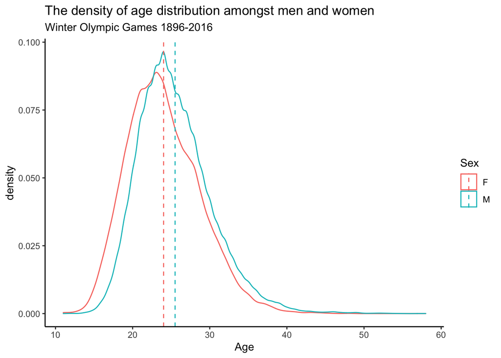

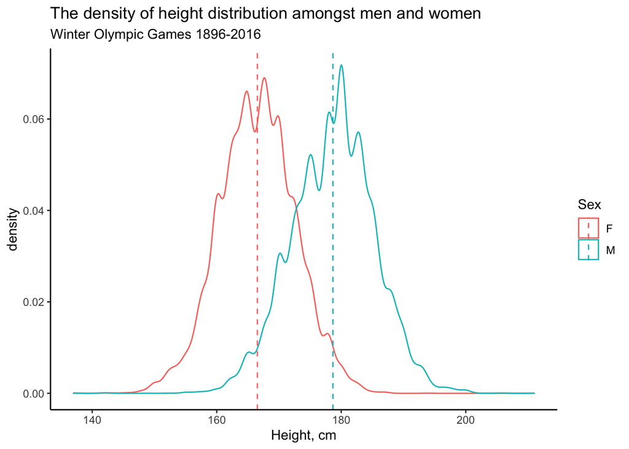

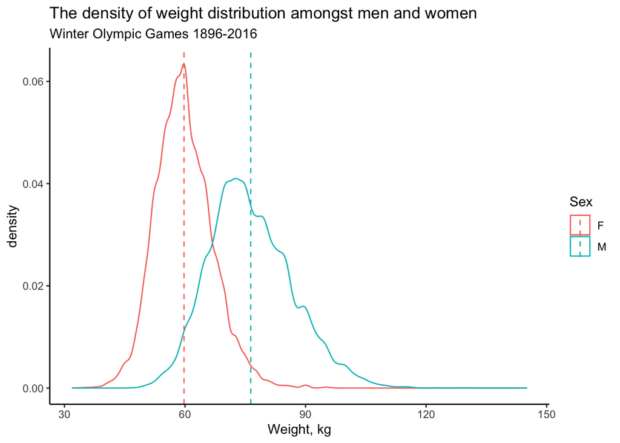

Now we will compare these variables between tro sexes:

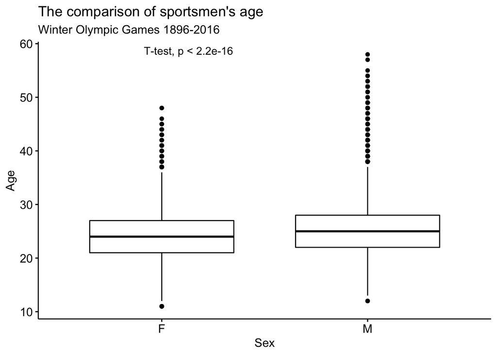

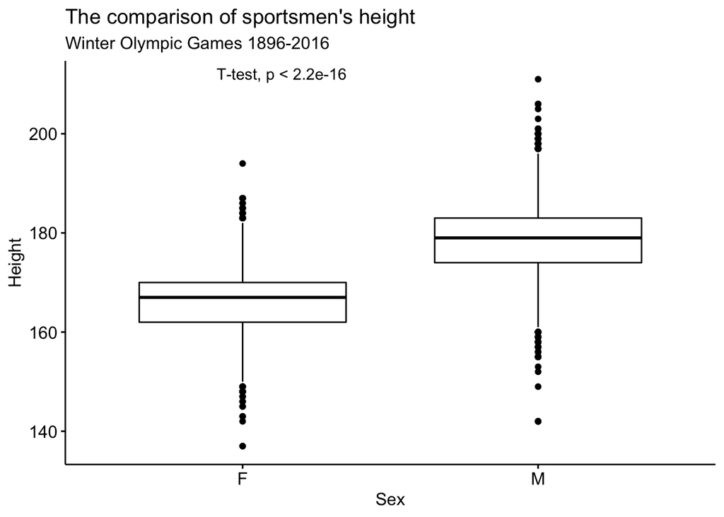

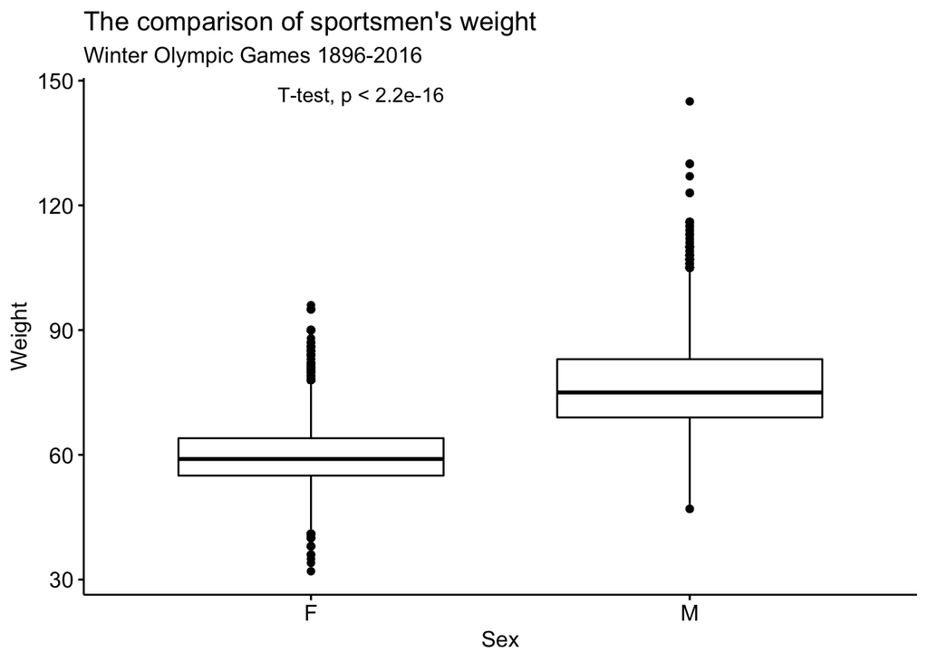

And the combined table:

```r
load_libs("kableExtra")
```

Comparison of the height, weight and age of men and women, participated in the winter olympic games.

| Variable | Sex | n | [min, max] | mean ± sd |
| --- | --- | --- | --- | --- |
| Height, cm | F | 13523 | [ 137 , 194 ] | 167 ± 6 |
| Height, cm | M | 26727 | [ 142 , 211 ] | 179 ± 7 |
| Weight, kg | F | 13334 | [ 32 , 96 ] | 60 ± 7 |
| Weight, kg | M | 26209 | [ 47 , 145 ] | 76 ± 10 |
| Age, years | F | 15073 | [ 11 , 48 ] | 24 ± 5 |
| Age, years | M | 33206 | [ 12 , 58 ] | 26 ± 5 |